# Chapter 3

0. Load libraries

```r
library(spData)
library(dplyr)
library(RQGIS)
data(us_states)
data(us_states_df)
```

1. Create a new object called us_states_name that contains only the NAME column from the us_states object. What is the class of the new object and what makes it geographic?

```r
us_states_name= us_states[, 2]
class(us_states_name)
```

```
[1] "sf"         "data.frame"
```

2. Select columns from the us_states object which contain population data. Obtain the same result using a different command (bonus: try to find three ways of obtaining the same result). Hint: try to use helper functions, such as contains or starts_with from dplyr (see ?contains).

```r
population1 = us_states[ , 5:6]

population2 = data.frame(us_states$total_pop_10, us_states$total_pop_15)
```

3. Find all states with the following characteristics (bonus find and plot them): Belong to the Midwest region. Belong to the West region, have an area below 250,000 km2 and in 2015 a population greater than 5,000,000 residents (hint: you may need to use the function units::set_units() or as.numeric()). Belong to the South region, had an area larger than 150,000 km2 or a total population in 2015 larger than 7,000,000 residents.

```r
found_states = us_states[us_states$REGION == "Midwest" | (us_states$REGION == "West" & us_states$AREA  < units::set_units(250000, km^2) |us_states$total_pop_15 > 5000000) | (us_states$REGION == "South" & (us_states$AREA < units::set_units(150000, km^2)|us_states$total_pop_15 > 7000000)),]
```

4. What was the total population in 2015 in the us_states dataset? What was the minimum and maximum total population in 2015?

```r
sum(us_states$total_pop_15)
```

```
[1] 314375347
```

```r
min(us_states$total_pop_15)
```

```
[1] 579679
```

```r
max(us_states$total_pop_15)
```

```
[1] 38421464
```

5. How many states are there in each region?

```r
nrow(us_states[us_states$REGION == "Midwest", ])
```

```
[1] 12
```

```r
nrow(us_states[us_states$REGION == "West", ])
```

```
[1] 11
```

```r
nrow(us_states[us_states$REGION == "Norteast", ])
```

```
[1] 9
```

```r
nrow(us_states[us_states$REGION == "South", ])
```

```
[1] 17
```

6. What was the minimum and maximum total population in 2015 in each region? What was the total population in 2015 in each region?

```r
sum(us_states[us_states$REGION == "Midwest", ]$total_pop_15)
```

```
[1] 67546398
```

```r
min(us_states[us_states$REGION == "Midwest", ]$total_pop_15)
```

```
[1] 721640
```

```r
max(us_states[us_states$REGION == "Midwest", ]$total_pop_15)
```

```
[1] 12873761
```

```r
sum(us_states[us_states$REGION == "West", ]$total_pop_15)
```

```
[1] 72264052
```

```r
min(us_states[us_states$REGION == "West", ]$total_pop_15)
```

```
[1] 579679
```

```r
max(us_states[us_states$REGION == "West", ]$total_pop_15)
```

```
[1] 38421464
```

```r
sum(us_states[us_states$REGION == "South", ]$total_pop_15)
```

```
[1] 118575377
```

```r
min(us_states[us_states$REGION == "South", ]$total_pop_15)
```

```
[1] 647484
```

```r
max(us_states[us_states$REGION == "South", ]$total_pop_15)
```

```
[1] 26538614
```

```r
sum(us_states[us_states$REGION == "Norteast", ]$total_pop_15)
```

```
[1] 55989520
```

```r
min(us_states[us_states$REGION == "Norteast", ]$total_pop_15)
```

```
[1] 626604
```

```r
max(us_states[us_states$REGION == "Norteast", ]$total_pop_15)
```

```
[1] 19673174
```

7. Add variables from us_states_df to us_states, and create a new object called us_states_stats. What function did you use and why? Which variable is the key in both datasets? What is the class of the new object?

```r
us_states_stats = left_join(us_states, us_states_df, by = c("NAME" = "state"))
class(us_states_stats)
```

```
[1] "sf"         "data.frame"
```

8. us_states_df has two more rows than us_states. How can you find them? (hint: try to use the dplyr::anti_join() function)

```r
anti_join(us_states_df, us_states, by= c("state" = "NAME"))
```

| state | median_income_10 | median_income_15 | poverty_level_10 | poverty_level_15 |
| --- | --- | --- | --- | --- |
| Alaska | 29509 | 31455 | 64245 | 72957 |
| Hawaii | 29945 | 31051 | 124627 | 153944 |

9. What was the population density in 2015 in each state? What was the population density in 2010 in each state?

```r
pop_density_15 = us_states$total_pop_15/as.numeric(us_states$AREA)
pop_density_10 = us_states$total_pop_10/as.numeric(us_states$AREA)

pop_density_15
```

```
 [1]   36.127786   22.493565   19.582469
 [4]  276.900364  130.059657   65.520897
 [7]    7.466293   70.141565   13.579734
[10]   37.804767  320.676491   24.794153
[13]   33.452701    2.664447    9.773012
[16]  439.210687  154.660883    3.939560
[19]   21.272605  109.001118   59.052713
[22]    4.220871   38.589593   25.199068
[25]   29.474967   21.484573   93.768733
[28]  178.788485 3633.263718   88.180609
[31]   21.225799   42.096925   15.541438
[34]  220.887166   65.515059   24.147135
[37]    9.334115   55.114234    6.618638
[40]   76.182958  108.134796   15.672536
[43]  384.119309   59.567250   13.205593
[46]   78.332684   39.817723   39.613278
[49]    2.288421
```

```r
pop_density_10
```

```
 [1]   35.245506   21.155478   18.128893
 [4]  273.248788  122.551303   61.999029
 [7]    7.051768   68.526513   13.187042
[10]   36.208365  309.749575   23.983155
[13]   32.771335    2.556892    9.195756
[16]  430.192291  151.174916    3.602281
[19]   20.308950  107.577964   55.763020
[22]    4.001976   35.351732   25.104723
[25]   29.305926   20.863438   89.414403
[28]  170.070353 3279.276889   87.301101
[31]   20.695697   41.029270   15.524659
[34]  212.167384   65.859926   23.774674
[37]    8.983392   54.687122    6.393175
[40]   71.740160  107.541194   14.967103
[43]  385.113820   57.141831   12.086048
[46]   74.396653   37.399936   38.894638
[49]    2.153803
```

10. How much has population density changed between 2010 and 2015 in each state? Calculate the change in percentages and map them.

```r
percent_change = ((pop_density_15 - pop_density_10) / pop_density_10)*100
percent_change
```

```
 [1]  2.5032407  6.3250142  8.0180092  1.3363558
 [5]  6.1267031  5.6805207  5.8783191  2.3568275
 [9]  2.9778641  4.4089310  3.5276612  3.3815320
[13]  2.0791535  4.2064660  6.2774106  2.0963640
[17]  2.3059164  9.3629235  4.7449773  1.3229042
[21]  5.8994181  5.4696784  9.1589873  0.3758062
[25]  0.5768138  2.9771461  4.8698307  5.1261917
[29] 10.7946612  1.0074412  2.5614112  2.6021810
[33]  0.1080845  4.1098598 -0.5236375  1.5666261
[37]  3.9041201  0.7810104  3.5266119  6.1929023
[41]  0.5519772  4.7132253 -0.2582382  4.2445607
[45]  9.2631215  5.2906021  6.4646822  1.8476584
[49]  6.2502406
```

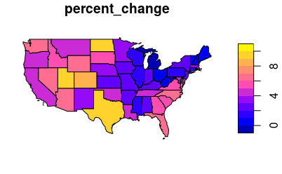

```r
# don't forget to map
us_states$percent_change= percent_change
plot(us_states["percent_change"], expandBB = c(.01, .01, 0.01, .01),lwd =1)
```

11. Change the columns’ names in us_states to lowercase. (Hint: helper functions - tolower() and colnames() may help.)

```r
names <- colnames(us_states)
colnames(us_states) = tolower(names)
```

12. Using us_states and us_states_df create a new object called us_states_sel. The new object should have only two variables - median_income_15 and geometry. Change the name of the median_income_15 column to Income.

```r
us_states_temp = left_join(us_states, us_states_df, by = c("name" = "state"))
us_states_sel = select(us_states_temp, "median_income_15", "geometry")
colnames(us_states_sel)[1] <- "Income"
```

13.Calculate the change in median income between 2010 and 2015 for each state. Bonus: What was the minimum, average and maximum median income in 2015 for each region? What is the region with the largest increase of the median income?

```r
income_percent_change = (us_states_df$median_income_15 - us_states_df$median_income_10)/ (us_states_df$median_income_10)*100
income_percent_change
```

```
 [1]  5.26073761  6.59459826 -0.96925640
 [4]  6.34069250 -0.63219025  4.72331006
 [7]  3.00080600  3.84865605 15.93693285
[10] -0.63678865 -0.03125488  3.69343797
[13]  3.02632730  4.78420269  3.60952916
[16]  9.53523120  6.30059153  5.77986726
[19]  8.89221421  6.07039476  3.90917264
[22]  2.85189482  2.27934045  5.91851371
[25]  7.08826615  4.83384933  8.54939503
[28]  8.01226608 -5.91934759  3.42519685
[31]  1.15229850  4.17074255  5.80553078
[34]  3.58961620 23.49598116  3.89911930
[37] 10.86704687  1.53619025  6.19186505
[40]  5.88059367  4.33738097 10.94932782
[43]  5.47769006  6.20520254  3.44334565
[46]  6.19420942  3.20332882  3.72649689
[49]  8.58617835  3.88371394 10.50343675
```

14. Create a raster from scratch with nine rows and columns and a resolution of 0.5 decimal degrees (WGS84). Fill it with random numbers. Extract the values of the four corner cells.

```r
random = raster(nrows = 9, ncol = 9, vals = runif(81, 0.0, 1.0), res= c(.5, .5), xmn = 0, ymn = 0, xmx = 4.5, ymx = 4.5)
res(random)
```

```
[1] 0.5 0.5
```

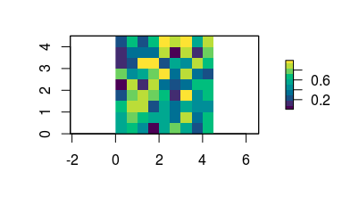

```r
plot(random, col = hcl.colors(10, palette = "viridis", alpha = NULL), maxpixels = 81)
```

```r
row_1 = getValues(random, row=1)
row_9 = getValues(random, row=9)
row_1[1]
```

```
[1] 0.2339946
```

```r
row_1[9]
```

```
[1] 0.831743
```

```r
row_9[1]
```

```
[1] 0.5788863
```

```r
row_9[9]
```

```
[1] 0.619461
```

15. What is the most common class of our example raster grain (hint: modal())?

```r
# this code is from the book to build grain
elev = raster(nrows = 6, ncols = 6, res = 0.5,
              xmn = -1.5, xmx = 1.5, ymn = -1.5, ymx = 1.5, vals = 1:36)
grain_order = c("clay", "silt", "sand")
grain_char = sample(grain_order, 36, replace = TRUE)
grain_fact = factor(grain_char, levels = grain_order)
grain = raster(nrows = 6, ncols = 6, res = 0.5,
               xmn = -1.5, xmx = 1.5, ymn = -1.5, ymx = 1.5,
               vals = grain_fact)

# apply modal to every factor
cellStats(grain, modal) %>%
  factorValues(grain, .)
```

| VALUE |
| --- |
| silt |

```r
factorValues(grain, modal(values(grain)))
```

| VALUE |
| --- |
| silt |

16. Plot the histogram and the boxplot of the data(dem, package = “RQGIS”) raster.

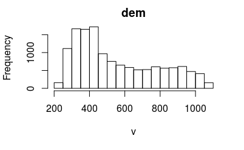

```r
library(RQGIS)
hist(dem)
```

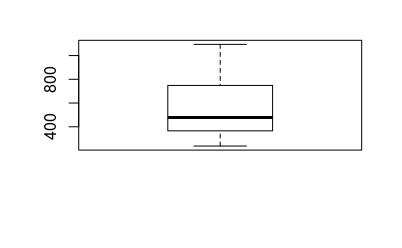

```r
boxplot(dem)
```